# MTH 412/512 - Ch8_t-bootstrap_skew.Rmd

**Example of using a bootstrap t-test for a non-normal distribution.**

Here, take a sample of size n=20 from  
$X\sim \mbox{Exp}(\lambda)$ with $\mu = E[X] = 1/\lambda$ and $\sigma^2 = \mbox{Var}[X]=1/\lambda^2$  
and treat this as the given data. Then find the bootstrap distribution from the data and use that to evaluate the p-value for the two-sided hypothesis test.

Generate a sample of size n:

```r
n <- 20
lambda <- 0.5
mu <- 1/lambda
sigma <- 1/lambda
set.seed(11)   # sets starting point for pseudorandom generator
data <- rexp(n,lambda)
data_mean <- mean(data)
data_sd <- sd(data)
data_max <- max(data)
data_min <- min(data)
```

theory mean = 2  
data mean = 2.9010401  
theory std dev = 2  
data std dev = 3.3027627

Plot the histogram of the sample and scaled version of the pdf

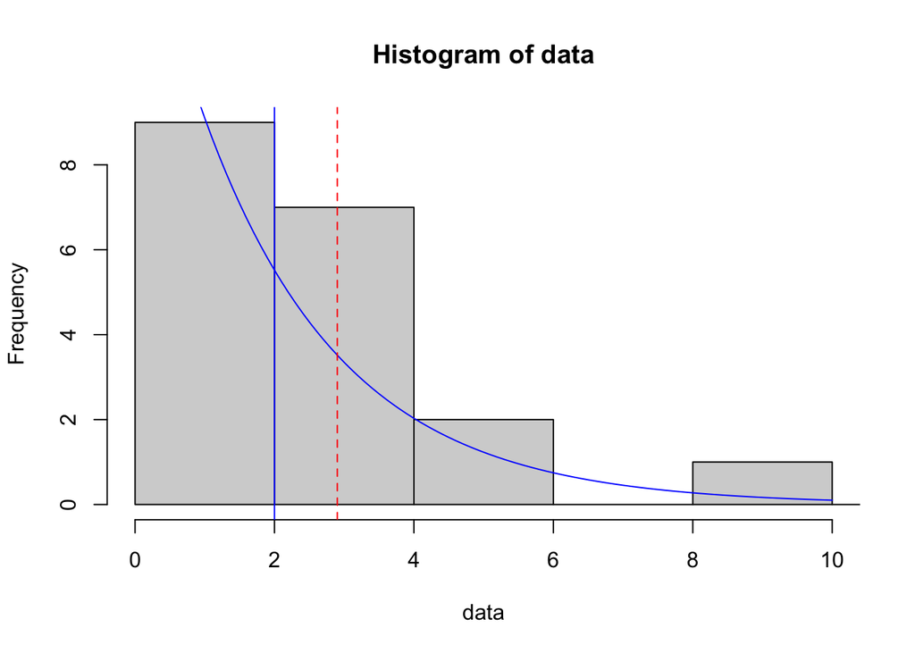

```r
hist(data,xlim=c(0,10))
xfine<-seq(0,10,length=101)
scale = 30
lines(xfine,scale*dexp(xfine,lambda),col='blue',type='l',xlab='x',ylab='pdf')
abline(v=mu,col='blue')
abline(v=data_mean,col='red',lty='dashed')
```

Note: Unless n is large, the mean of the data (red dashed) is not necessarily close to the theoretical mean (blue solid).

**Exact result for p-value from Gamma distribution**  
Note, the Exponential distribution $X \sim \mbox{Exp}(\lambda)$ is a special case of the Gamma distribution $G \sim \mbox{Gamma}(r,\lambda)$ with $r=1$ (see Appendix B of textook).

Since the result for the sampling mean for the Gamma distribution is known:  
$\bar{G} \sim \mbox{Gamma}(nr,n \lambda)$,  
we have the exact result for the sampling distribution of the Exponential distribution as  
$\bar{X} \sim \mbox{Gamma}(n,n\lambda)$.

Thus the exact two-sided p value can be calculated from

```r
pexact_minus = pgamma(data_mean,n,n*lambda)
pexact_plus=1 - pexact_minus
pexact2 = 2*(min(pexact_minus,pexact_plus))
```

pexact_minus = 0.9675011  
pexact_plus = 0.0324989  
pexact2 = 0.0649978

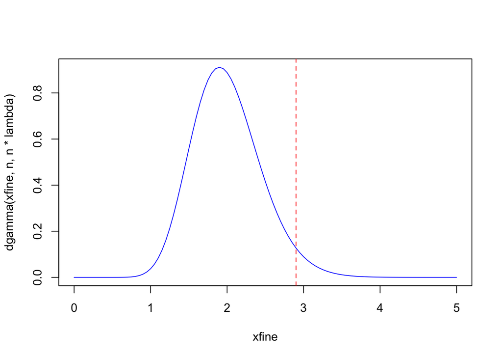

```r
xfine <- seq(0,5,length=101)
plot(xfine,dgamma(xfine,n,n*lambda),col='blue',type='l')
abline(v=data_mean,col='red',lty='dashed')
```

**Bootstrap distribution for T-statistic**  
We now use the bootstrap approximation for the T-statistic  
$T = \frac{\bar{X} - \mu}{S/\sqrt{n}}$,  
where the bootstrap distribution is based on resampling of the data with replacement and using  
$T^* = \frac{\bar{X^*} - \bar{x}}{S^*/\sqrt{n}}$  
where $\bar{X^*}$ is the mean and $S^*$ is the standard deviation of each resample. By computing $T^*$ using $\bar{x}$ instead of $\mu$, we obtain the shape of the bootstrap distribution relative to the mean of the data.

Then, for determining the p-value, we use  
$t = \frac{\bar{x}-\mu}{s/\sqrt{n}}$  
to determine how large the observed $\bar{x}$ is relative to the assumed mean of the null distribution $\mu$.

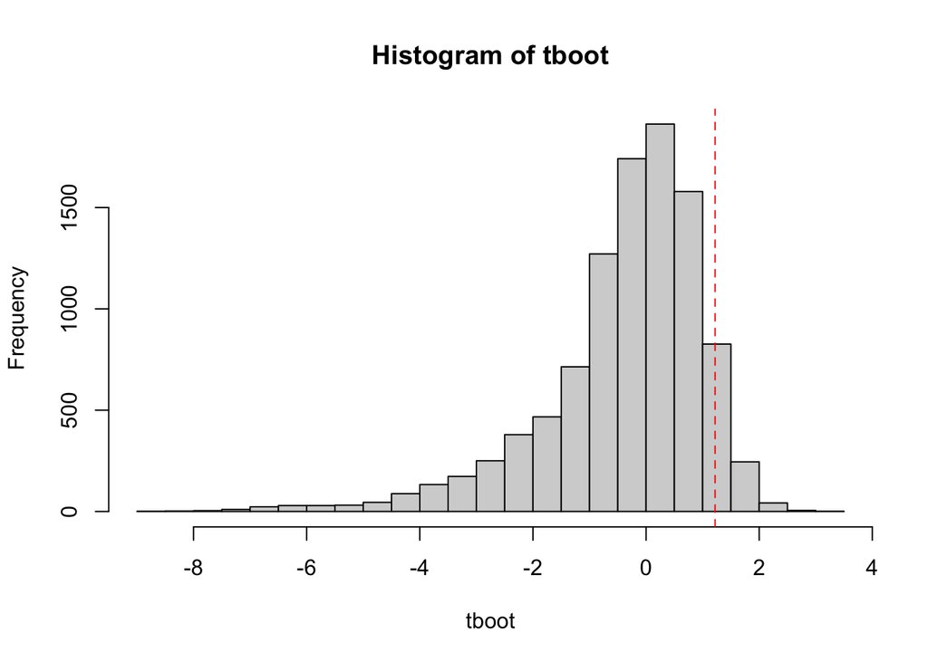

```r
N <- 10**4  # number of samples
tboot <- numeric(N) # array for bootstrap dist
# loop to create sample, calculate t statistic,
for (i in seq(1,N)) {
  resample <- sample(data,n,replace=TRUE)
  xbar <- mean(resample)
  s <- sd(resample)
  tboot[i] <- (xbar-data_mean)/(s/sqrt(n)) # gives shape relative to data_mean
}
t_observed <- (data_mean - mu)/(data_sd/sqrt(n))
hist(tboot,breaks=20)
abline(v=t_observed,col='red',lty='dashed')
```

Note the skewness of the bootstrap T distribution is reversed from the sampling distribution of $\bar{X}$. This is because of the variability of the standard deviation of the resamples. Because all the data is positive, resamples with many small values are biased to have a smaller standard deviation, leading to larger values of $T^* = \frac{\bar{X^*} - \bar{x}}{S^*/\sqrt{n}}$

The p-value can be estimated from the bootstrap distribution from $P(\bar{X} \le \bar{x}) \approx P(T^* \le t)$.

```r
pt_minus <- (sum(tboot <= t_observed) + 1)/(N+1)
pt_plus <- (sum(tboot >= t_observed)+1)/(N+1)
pt2 <- 2*min(pt_minus,pt_plus) # two-sided p value
```

**Standard T-test**

Here it is assumed that the data is from a normal distribution with unknown mean and variance.

```r
t <- (data_mean - mu)/(data_sd/sqrt(n))
pstd_minus = pt(t,df=n-1)
pstd_plus = 1 - pstd_minus
pstd2 = 2*min(pstd_minus,pstd_plus)
```

**Comparison of methods**

| Method | P minus | P plus | P two-sided |
| --- | --- | --- | --- |
| Xbar exact | 0.9675011 | 0.0324989 | 0.0649978 |
| T bootstrap | 0.9361064 | 0.0639936 | 0.1279872 |
| standard T | 0.8813153 | 0.1186847 | 0.2373694 |

According to Sec 8.2 of the text, the error for bootstrap t-test scales like 1/n for n large, whereas the error for the standard T-test scales like $1/\sqrt{n}$ for skewed distributions. Both approximations become exact as $n\rightarrow \infty$ but the T bootstrap converges faster.